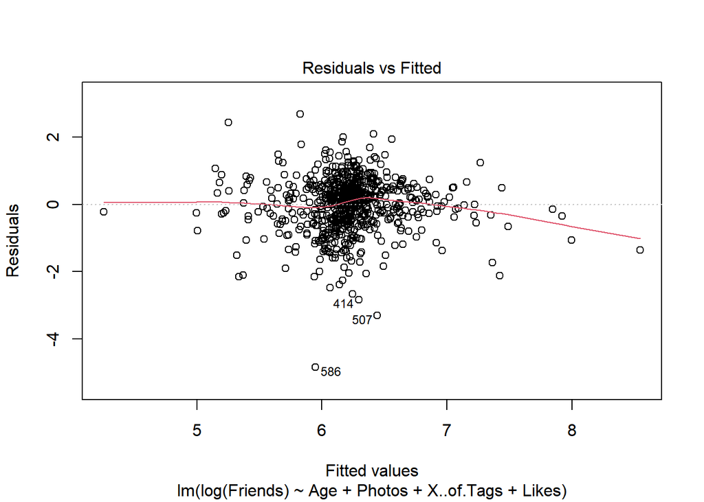

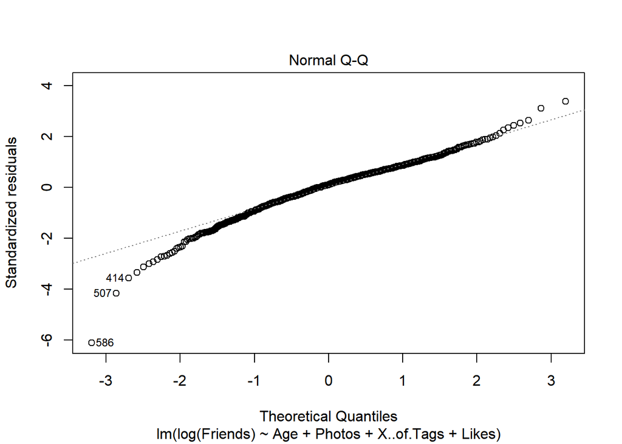

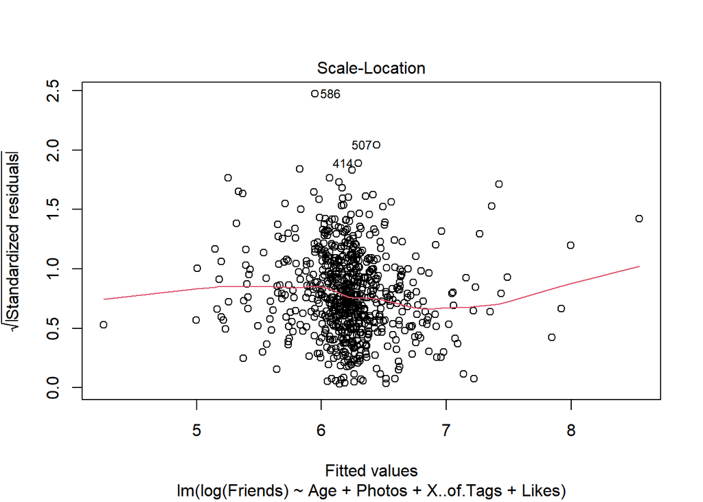

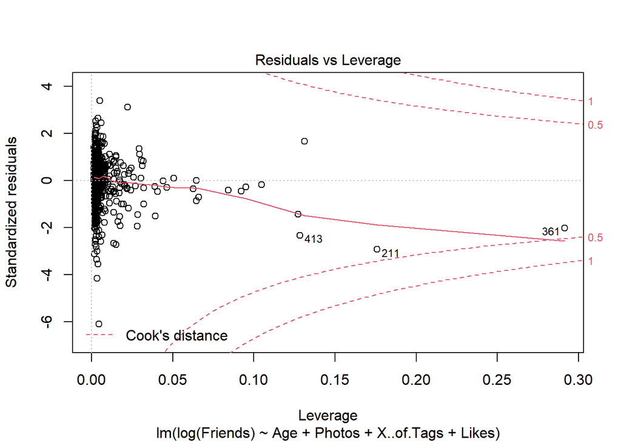

```r
plot(model4)
```

#Predict the number of friends with the help of model4.Let’s predict for the number of friends for row number 14.

```r
exp(predict(model4,list(Age=24,X..of.Tags=504, Likes=113, Photos=402)))
```

```
##        1
## 488.1743
```

#Comment on section 4: #Correlation heatmap: Replies and Posts are highly correlated (0.9). Children and Age is highly correlated (0.6). Similarly Albums is correlated with number of Photos (0.8) and number of tags (0.5). Other data in matrix shows weak correlation among the variables.

#Multiple Regression model: 95% confidence interval, alpha=0.05, two tailed t-test. #Model1: We performed multiple regression (model1) with all non-binary independent variable to predict the number of friends. The adjusted R square is 0.133 which says that 13.3% of variation is explained by the model. Rest of the variation is unexplained by the model. P-value of Age, Number of tags, Gender, Likes have significant p value (less than 0.05).

#Model2: To identify the significant predictors, I started removing most insignificant predictors that has higher p-value (greater than 0.05). I removed Children, Albums and Events. The adjusted R square is 0.1326 which says that 13.26% of variation is explained by the model. Since there is still insignificant predictors in the model, I further eliminated the predictors.

#Model3: To identify further significant independent variable, I removed rest two insignificant predictors (Replies, Posts) that has p-value less than 0.05. At this time, We have all predictors which have p-value less than 0.05. The adjusted R square is 0.131 which says that 13.1% of variation is explained by the model.

#Model4: To improve the model further, i redefined model where log(response variable) is linear function of predictors.The adjusted R square is improved and it is 0.1733 which says that 17.33% of variation is explained by the model. This model is better than our other model as R square is increased from 13% to 17%.

#Model 4 describes best fit among all other model described above. Predictor’s P-value is significant. The Significant predictors are Age, Photos, X..of.Tags, Likes. Also, the predicted value for number of friends is better than the model.

#Residual analysis: For regression, four criteria should be met: linearity, non-autocorrelation, normality of error and equal variance. I have plotted the diagnostic plots for model1 and model3. Since, there is no improvement in the residual plots in model1 and model3. I have used model 4 where normal QQ plot is much better than previous models. Residual vs fitted plot: The fitted line is approximate straight line means assumption of linearity is met. Normal Q-Q plot: Normal Quantile-Quantile is ok but not perfect straight line. Errors are not perfectly normally distributed but improved compared to model 1 and model3. Scale Location: Scale location shows the straight line with slight curve. It shows somewhat heteroscedastic trend but improved as compared to model1 and model3. Residual vs Leverage: There are no influential points in the graph which are outside the Cook’s distance line and need revaluation of the model. This graph is much better than previous models(model1 and model3)

#Conclusion #1. Significant predictors to predict the number of friends is Age, Photos, X..of.Tags, Likes. #2. All non-binary variables are right skewed, where mean is greater than median. #3. As the sign of co-efficient for Age is negative which shows that older people have a smaller number of friends in the Facebook compared to young group (21years to 25 years). #4. Since R square of the model is 17% which is low. Predictors are not good enough in the dataset to predict the number of friends. #5. Sign of the co-efficient of number of tags, photos, likes is positive. Number of friends will be more if number of tags, photos and likes are more in Facebook.